# MBON Retrieval and Redeployment Cruise

September 11, 2025 *R/V Daiber* Lewes, DE

### Crew

- **Aaron Carlisle** *UD*
  - Chief Scientist
- **Michael Cyrana** *JHU-APL*
  - eDNA Lead
- **Caroline Tribble** *UMCES*
  - Acoustics and Biotelemetry Lead
- **Evan Falgowski** *UD*
  - Captain of *R/V Daiber*
- **Tess Avery** *UD*
  - Field Technician

### Contact Information

- (831) 601-7461 | carlisle@udel.edu
- (443) 257-9276 | Michael.Cyrana@jhuapl.edu
- (301) 938-0265 | ctribble@umces.edu
- (610) 563-1040 | evanfal@udel.edu
- (617) 599-9681 | tmavery@udel.edu

# Schedule, in brief

### 10 September

- Crew arrives. Loads gear on *R/V Daiber*.

### 11 September

- 06:00 Arrive at R/V Daiber
- 06:30 - 18:25 eDNA sampling at all sites, mooring retrieval and redeployment for sites T-2C, MBON5, MBON5*, A-5C, MBON3, T-1C, and MBON1.

[interactive chart not shown]

# Cruise plan, calculated at 17 knots

- 06:00 Meet at *R/V Daiber*
- 06:30 Depart Lewes for **T-3C**
- **38 20.154, -74 21**
- 09:20 Arrive **T-3C**. Conduct eDNA sampling.
- 09:25 Finish eDNA sampling.
- 09:30 Complete operations. Depart for **T-2C**
- **38 20.16, -74 30.3**
- 10:20 Arrive **T-2C**. Conduct eDNA sampling.
- 10:25 Once eDNA sampling is finished, retrieve current and redeploy new mooring.
- 10:50 Complete operations. Depart for **MBON5**
- **38 20.16, -74 34.662**
- 11:05 Arrive **MBON5**. Conduct eDNA sampling.
- 11:10 Once eDNA sampling is finished, retrieve current and redeploy new mooring.
- 11:35 Complete operations. Depart for **MBON5***
- **38 20.166, -74 34.764**
- 11:40 Arrive **MBON5***.
- 11:45 Retrieve offset MBON5 mooring.
- 11:50 Complete operations. Depart for **MBON4**
- **38 20.166, -74 39.018**
- 12:25 Arrive **MBON4**. Conduct eDNA sampling.
- 12:30 Finish eDNA sampling.
- 12:35 Complete operations. Depart for **A-5C**
- **38 20.16, -74 43.236**
- 13:10 Arrive **A-5C**. Conduct eDNA sampling.
- 13:15 Once eDNA sampling is finished, retrieve current and redeploy new mooring.
- 13:40 Complete operations. Depart for **MBON3**
- **38 20.16, -74 47.898**
- 13:55 Arrive **MBON3**. Conduct eDNA sampling.
- 14:00 Once eDNA sampling is finished, retrieve current and redeploy new mooring.
- 14:25 Complete operations. Depart for **MBON2**
- **38 20.16, -74 52.416**
- 14:40 Arrive **MBON2**. Conduct eDNA sampling.
- 14:45 Finish eDNA sampling.
- 14:50 Complete operations. Depart for **T-1C**
- **38 20.16, -74 56.946**
- 15:25 Arrive **T-1C**. Conduct eDNA sampling.
- 15:30 Once eDNA sampling is finished, retrieve current and redeploy new mooring.
- 15:55 Complete operations. Depart for **MBON1**
- **38 20.16, -75 0.9**
- 16:10 Arrive **MBON1**. Conduct eDNA sampling.
- 16:15 Once eDNA sampling is finished, retrieve current and redeploy new mooring.
- 16:40 Complete operations. Depart for **Lewes**
- 18:25 Arrive **Lewes**.

# Distances

Distance, nautical miles

|  | Lewes | T-3C | T-2C | MBON5 | MBON5* | MBON4 | A-5C | MBON3 | MBON2 | T-1C | MBON1 |
| --- | --- | --- | --- | --- | --- | --- | --- | --- | --- | --- | --- |
| Lewes | 0.00 | 47.24 | 41.68 | 39.27 | 39.21 | 37.01 | 35.01 | 33.04 | 31.42 | 30.12 | 29.30 |
| T-3C | 47.24 | 0.00 | 7.30 | 10.72 | 10.80 | 14.14 | 17.45 | 21.11 | 24.66 | 28.21 | 31.32 |
| T-2C | 41.68 | 7.30 | 0.00 | 3.42 | 3.50 | 6.84 | 10.15 | 13.81 | 17.36 | 20.91 | 24.02 |
| MBON5 | 39.27 | 10.72 | 3.42 | 0.00 | 0.08 | 3.42 | 6.73 | 10.39 | 13.94 | 17.49 | 20.59 |
| MBON5* | 39.21 | 10.80 | 3.50 | 0.08 | 0.00 | 3.34 | 6.65 | 10.31 | 13.86 | 17.41 | 20.51 |
| MBON4 | 37.01 | 14.14 | 6.84 | 3.42 | 3.34 | 0.00 | 3.31 | 6.97 | 10.52 | 14.07 | 17.18 |
| A-5C | 35.01 | 17.45 | 10.15 | 6.73 | 6.65 | 3.31 | 0.00 | 3.66 | 7.21 | 10.76 | 13.86 |
| MBON3 | 33.04 | 21.11 | 13.81 | 10.39 | 10.31 | 6.97 | 3.66 | 0.00 | 3.55 | 7.10 | 10.21 |
| MBON2 | 31.42 | 24.66 | 17.36 | 13.94 | 13.86 | 10.52 | 7.21 | 3.55 | 0.00 | 3.56 | 6.66 |
| T-1C | 30.12 | 28.21 | 20.91 | 17.49 | 17.41 | 14.07 | 10.76 | 7.10 | 3.56 | 0.00 | 3.10 |
| MBON1 | 29.30 | 31.32 | 24.02 | 20.59 | 20.51 | 17.18 | 13.86 | 10.21 | 6.66 | 3.10 | 0.00 |

Distance, time at 17 kts

|  | Lewes | T-3C | T-2C | MBON5 | MBON5* | MBON4 | A-5C | MBON3 | MBON2 | T-1C | MBON1 |
| --- | --- | --- | --- | --- | --- | --- | --- | --- | --- | --- | --- |
| Lewes | - | 02 h 50 m | 02 h 30 m | 02 h 20 m | 02 h 20 m | 02 h 15 m | 02 h 05 m | 02 h 00 m | 01 h 55 m | 01 h 50 m | 01 h 45 m |
| T-3C | 02 h 50 m | - | 00 h 30 m | 00 h 40 m | 00 h 40 m | 00 h 50 m | 01 h 05 m | 01 h 15 m | 01 h 30 m | 01 h 40 m | 01 h 55 m |
| T-2C | 02 h 30 m | 00 h 30 m | - | 00 h 15 m | 00 h 15 m | 00 h 25 m | 00 h 40 m | 00 h 50 m | 01 h 05 m | 01 h 15 m | 01 h 25 m |
| MBON5 | 02 h 20 m | 00 h 40 m | 00 h 15 m | - | 00 h 05 m | 00 h 15 m | 00 h 25 m | 00 h 40 m | 00 h 50 m | 01 h 05 m | 01 h 15 m |
| MBON5* | 02 h 20 m | 00 h 40 m | 00 h 15 m | 00 h 05 m | - | 00 h 15 m | 00 h 25 m | 00 h 40 m | 00 h 50 m | 01 h 05 m | 01 h 15 m |
| MBON4 | 02 h 15 m | 00 h 50 m | 00 h 25 m | 00 h 15 m | 00 h 15 m | - | 00 h 15 m | 00 h 25 m | 00 h 40 m | 00 h 50 m | 01 h 05 m |
| A-5C | 02 h 05 m | 01 h 05 m | 00 h 40 m | 00 h 25 m | 00 h 25 m | 00 h 15 m | - | 00 h 15 m | 00 h 30 m | 00 h 40 m | 00 h 50 m |
| MBON3 | 02 h 00 m | 01 h 15 m | 00 h 50 m | 00 h 40 m | 00 h 40 m | 00 h 25 m | 00 h 15 m | - | 00 h 15 m | 00 h 30 m | 00 h 40 m |
| MBON2 | 01 h 55 m | 01 h 30 m | 01 h 05 m | 00 h 50 m | 00 h 50 m | 00 h 40 m | 00 h 30 m | 00 h 15 m | - | 00 h 15 m | 00 h 25 m |
| T-1C | 01 h 50 m | 01 h 40 m | 01 h 15 m | 01 h 05 m | 01 h 05 m | 00 h 50 m | 00 h 40 m | 00 h 30 m | 00 h 15 m | - | 00 h 15 m |
| MBON1 | 01 h 45 m | 01 h 55 m | 01 h 25 m | 01 h 15 m | 01 h 15 m | 01 h 05 m | 00 h 50 m | 00 h 40 m | 00 h 25 m | 00 h 15 m | - |

# Coordinates from April ’25 Deployment

| **Sites** | **Latitude** | **Longitude** | **Moored Data types** | **Moored instruments** | **VR2AR Release # for retrieval** |
| --- | --- | --- | --- | --- | --- |
| **T-3C** | 38º 20.154’ | -74º 21.0’ | biotelemetry, **PAM** | VR2AR, **LS-1X** | **Not retrieving yet** |
| **T-2C** | 38º 20.16’ | -74º 30.3’ | biotelemetry, **PAM** | VR2AR, **F-POD** | 553508 |
| MBON5 | 38º 20.16’ | -74º 34.662’ | biotelemetry | VR2AR | 546457 |
| MBON5* | 38º 20.16’ | -74º 34.764’ | biotelemetry | VR2AR | 553507 |
| **MBON4** | 38º 20.166’ | -74º 39.018’ | biotelemetry, **PAM** | VR2AR, **LS-1** | **Not retrieving yet** |
| **A-5C** | 38º 20.16’ | -74º 43.236’ | biotelemetry, **PAM** | VR2AR, **F-POD** | 546638 |
| MBON3 | 38º 20.16’ | -74º 47.898’ | biotelemetry | VR2AR | 546304 |
| **MBON2** | 38º 20.16’ | -74º 52.416’ | biotelemetry, **PAM** | VR2AR, **LS-1** | **Not retrieving yet** |
| **T-1C** | 38º 20.16’ | -74º 56.946’ | biotelemetry, **PAM** | VR2AR, **F-POD** | 546464 |
| MBON1 | 38º 20.16’ | -75º 0.9’ | biotelemetry | VR2AR | 546465 |

# Retrieval Table

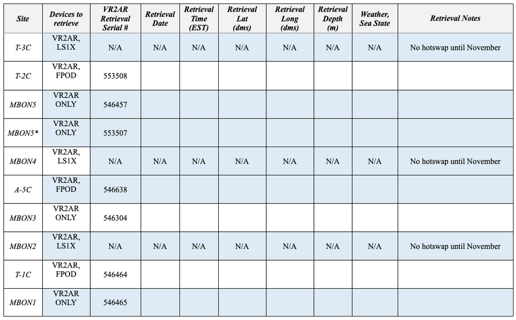

# Deployment Table

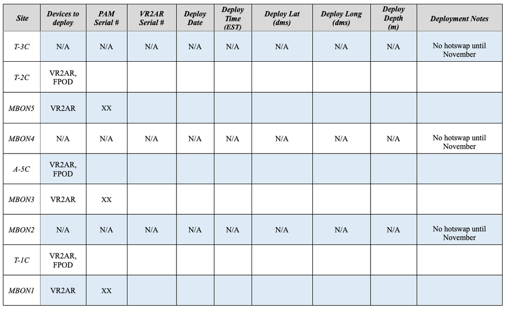

# Mooring Configurations

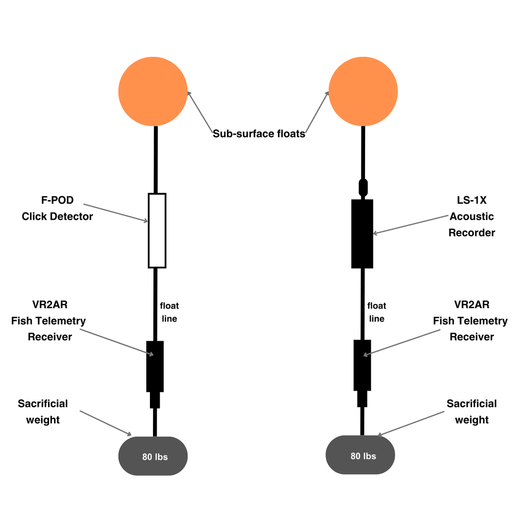

# PAM Device Set-up

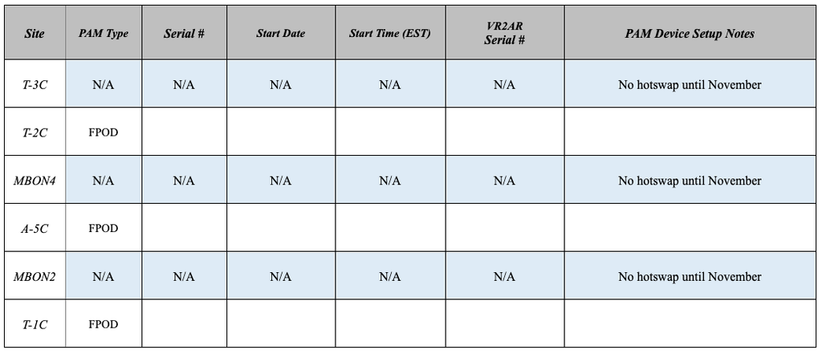

# Supply List

🔲 6 VR2ARs

🔲 3 F-PODS

🔲 6 large subsurface buoys

🔲 6 sacrificial weights (ranging 80-100 lb)

🔲 Zip Ties - large, medium, and small sizes

🔲 Total of 30 D cell alkaline batteries for F-PODs

🔲 F-POD microsd memory cards

🔲 F-POD battery springs

🔲 Desiccant packets for PAM devices

🔲 F-POD opening rods

🔲 Garmin handheld GPS

🔲 Datasheets

🔲 Foul weather gear

🔲 Boat shoes

🔲 Life jackets

🔲 Sharpies

🔲 Toolbox

🔲 Work gloves

🔲 VR100 Deckbox

🔲 VR100 Hydrophone